# Ecosystem Service Flood Control | Norway

Magnus Merkle (SSB), with Marte Lindseth (SSB), Erik Stange (NINA), Lavinia Svae (SSB) and Trine Randen (SSB)

Naturregnskapsprosjekt, 6. October 2025

# Changelog

Changes since version 5:

- Intermediate maps of service provision now included in the output directory
- Intermediate map of runoff retention now included in the output directory

# Abstract and Limitation

In this notebook we quantify the ecosystem service of flood control for the Norwegian mainland. Most operations are executed with functions from R packages dplyr and terra. The notebook is created on the basis of the following sources:

- Vallecillo et al. (2019) Ecosystem services accounting Part II Pilot accounts for crop and timber provision, global climate regulation and flood control. European Commission: JRC Technical Reports.
- EC (2023) Guidance note to account for flood control ecosystem service - 1st Draft. Agenda Item 6, Task Force on Ecosystem Accuonting, 28-29 November 2023.
- Immerzeel & Korkou (2024) Evaluation of the INCA-Tool for the purpose of ecosystem services accounting in Norway. EU Grants Project 2022-NO-EGD- Work Package 2. Norwegian Institute for Nature Research

The quantification process is implemented with reference to the work done by Harry Hodgins, Statistics Ireland. Harry has quantified ES flood control for Ireland using R. We do not copy the Statitics Ireland script in every aspect, but we use it as inspiration for the approach implemented here.

The quantification process follows the EC guidance note. It is important to note that the objective of the process is to identify the contribution of different ecosystems to the provision of flood control (i.e. reduced flood risk) and how this provision changes over time. The process is not designed to provide accurate predictions of the spatial pattern of flood risk and flood risk mitigation at fine spatial resolution. It is not a dynamic hydrological model, but rather an accounting exercise. Therefore, the resulting maps and tables should be interpreted with care and with the limitations of the process in mind. They do not provide accurate spatial accounts of the probability of flood damage.

# 1. Filepaths and Functions

The main functions we use are part of dplyr and terra.

```r
# make space
rm(list = ls())
# packages
library(dplyr)
library(tidyr)
library(terra)
library(sf)
library(knitr)
library(viridisLite)
# filepath
dfp<-file.path("C:","Users","muk",
               paste0("OneDrive - Statistisk sentralbyr","\U00E5"),
               "data","INCA")
# file path to results
rfp<-file.path("C:","Users","muk",
               paste0("OneDrive - Statistisk sentralbyr","\U00E5"),
               "Projects","Naturregnskap","Flomkontroll","Norway_R","output_maps")
# A function to extract levels vectors from factor data stored in rasters
# rst is raster file, lrn is layer name
extr_lvl_from_raster_lyr<-function(rst,lrn){
  if(is.factor(rst[[lrn]])){
    v1 <- as.vector(values(rst[[lrn]]))
    v2 <- as.vector(levels(rst[[lrn]]))[[1]]
    v3 <- v2$value[v1]
    return(v3)
  } else {
    return(as.vector(values(rst[[lrn]])))
  }
}
gc()
```

# 2. Data Sources

Here is a table of data sources used in this project.

```r
dfs<-data.frame(matrix(nrow=10,ncol=8))
colnames(dfs) <- c("Input to","Data","Name","Provider","Resolution","Year","Future Updates","Notes")

dfs[1,]<-c("SPA and SDA",
           "Reference land cover map (LCM) with lookup table",
           "Grunnkart_OT",
           "Kartverket, NIBIO, SSB, Mdir",
           "100m grid",
           "2024",
           "2025",
           "This is probably the most important input because we derive ecosystems, curve numbers, and economic assets from it. Updates should ideally be used to quantify changes in service flows over time. Comparability over time would be relevant for this purpose.")
dfs[2,]<-c("SPA",
           "Hydrological soil type map",
           "hydro_soilgroup_ INCA_EPSG3035",
           "Eurostat (INCA default version_2_2)",
           "100m grid (rescaled?)",
           "Unknown",
           "Unknown",
           "This map is rather coarse, containing only four categories. A part of it in Northern Norway is missing. It would probably be good to replace this with something more accurate/specific for Norway.")
dfs[3,]<-c("SPA",
           "Curve Number Lookup Table",
           "curve_number_per_ landcover_soil",
           "Eurostat (INCA default version_2_2)",
           "Not spatial",
           "Probably not relevant",
           "Not required",
           "Some Norwegian land cover categories are not included in the current table. For example: glaciers. It would be good to update the table so it contains all land cover categories that exist in Norway. Alternatively it would be good with a curve number lookup table for all categories reported in the Norwegian LCM. Then we could avoid the translation into CORINE categories.")
dfs[4,]<-c("SPA",
           "Impervious Density Map",
           "IMD_2018_100m_ eu_03035_V2_0_INCA_ 100m_EPSG3035",
           "Eurostat (INCA default version_2_2)",
           "100m grid (rescaled?)",
           "2018",
           "Unknown",
           "Here as well it might be possible to get hold of better data for the Norwegian context.")
dfs[5,]<-c("SPA and service flow",
           "Slope Map",
           "dt1_slope_INCA_ EPSG3035_ 100m_Byte",
           "European Space Agency (INCA default version_2_2)",
           "100m grid (rescaled)",
           "Probably not relevant",
           "Probably not relevant",
           "We could consider trying a finer resolution slope map in the flow quantification module. To test whether this might make results more accurate. Either using Norwegian elevation data, or by importing the original copernicus data.")
dfs[6,]<-c("SPA",
           "Riparian Zones Map",
           "RiparianZonesEU_ INCA_EPSG3035",
           "EC JRC (INCA default version_2_2)",
           "100m grid (rescaled?)",
           "Unknown",
           "Unknown",
           "If NVE has more accurate data for riparian zones we could try replacing this input. Also: if such zones can change over time, it would be relevant to update this data input over time.")
dfs[7,]<-c("SDA",
           "Flood Plains Map",
           "Flom_AktsomhetOmr",
           "NVE",
           "Vector data (rescaled)",
           "Probably not relevant",
           "Probably not relevant",
           "This is probably the best data we can use for the Norwegian context. Alternatively we could use areas where actual floods have happened.")
dfs[8,]<-c("SDA",
           "Population Map",
           "GHS_POP_E2020_ GLOBE_R2023A_ 54009_100_V1_0",
           "GHSL (INCA default version_2_2)",
           "100m grid (rescaled)",
           "2020",
           "Yes (every 5 years)",
           "This is another key input which should be varied over time to quantify changes in service flow.")
dfs[9,]<-c("Service Flow",
           "Elevation Map",
           "dt1_dem_INCA_ EPSG3035_100m",
           "European Space Agency (INCA default version_2_2)",
           "100m grid (rescaled)",
           "Probably not relevant",
           "Probably notrelevant",
           "We could try a finer resolution map to see whether that changes results. We could also include areas outside Norway if cross-border flows are flood-relevant for Norway.")
dfs[10,]<-c("Service Flow",
           "Various shapefiles (municipalities, NUTS 2 regions, catchment areas",
           "Various",
           "Various",
           "Vectors",
           "Not relevant",
           "Not relevant",
           "Only to retrieve results for specific subnational regions.")
#print
kable(dfs)
```

| Input to | Data | Name | Provider | Resolution | Year | Future Updates | Notes |
| --- | --- | --- | --- | --- | --- | --- | --- |
| SPA and SDA | Reference land cover map (LCM) with lookup table | Grunnkart_OT | Kartverket, NIBIO, SSB, Mdir | 100m grid | 2024 | 2025 | This is probably the most important input because we derive ecosystems, curve numbers, and economic assets from it. Updates should ideally be used to quantify changes in service flows over time. Compa… |
| SPA | Hydrological soil type map | hydro_soilgroup_ INCA_EPSG3035 | Eurostat (INCA default version_2_2) | 100m grid (rescaled?) | Unknown | Unknown | This map is rather coarse, containing only four categories. A part of it in Northern Norway is missing. It would probably be good to replace this with something more accurate/specific for Norway. |
| SPA | Curve Number Lookup Table | curve_number_per_ landcover_soil | Eurostat (INCA default version_2_2) | Not spatial | Probably not relevant | Not required | Some Norwegian land cover categories are not included in the current table. For example: glaciers. It would be good to update the table so it contains all land cover categories that exist in Norway. A… |
| SPA | Impervious Density Map | IMD_2018_100m_ eu_03035_V2_0_INCA_ 100m_EPSG3035 | Eurostat (INCA default version_2_2) | 100m grid (rescaled?) | 2018 | Unknown | Here as well it might be possible to get hold of better data for the Norwegian context. |
| SPA and service flow | Slope Map | dt1_slope_INCA_ EPSG3035_ 100m_Byte | European Space Agency (INCA default version_2_2) | 100m grid (rescaled) | Probably not relevant | Probably not relevant | We could consider trying a finer resolution slope map in the flow quantification module. To test whether this might make results more accurate. Either using Norwegian elevation data, or by importing t… |
| SPA | Riparian Zones Map | RiparianZonesEU_ INCA_EPSG3035 | EC JRC (INCA default version_2_2) | 100m grid (rescaled?) | Unknown | Unknown | If NVE has more accurate data for riparian zones we could try replacing this input. Also: if such zones can change over time, it would be relevant to update this data input over time. |
| SDA | Flood Plains Map | Flom_AktsomhetOmr | NVE | Vector data (rescaled) | Probably not relevant | Probably not relevant | This is probably the best data we can use for the Norwegian context. Alternatively we could use areas where actual floods have happened. |
| SDA | Population Map | GHS_POP_E2020_ GLOBE_R2023A_ 54009_100_V1_0 | GHSL (INCA default version_2_2) | 100m grid (rescaled) | 2020 | Yes (every 5 years) | This is another key input which should be varied over time to quantify changes in service flow. |
| Service Flow | Elevation Map | dt1_dem_INCA_ EPSG3035_100m | European Space Agency (INCA default version_2_2) | 100m grid (rescaled) | Probably not relevant | Probably notrelevant | We could try a finer resolution map to see whether that changes results. We could also include areas outside Norway if cross-border flows are flood-relevant for Norway. |
| Service Flow | Various shapefiles (municipalities, NUTS 2 regions, catchment areas | Various | Various | Vectors | Not relevant | Not relevant | Only to retrieve results for specific subnational regions. |

```r
# clean up
rm(dfs)
```

# 3. Service Provision (SPA)

## 3.1 Overview

The first step in the quantification of flood control is to create a raster map of potential runoff retention. This map is a key input to the ensuing steps. We start from the Norwegian land cover map and a European Hydrological Soil Charateristics map. Each combination of land cover and soil characteristic is associated to a Curve Number (CN) value - an index of infiltration/runoff. The resulting curve number raster map is then further refined using various inputs. Once the runoff retention map is obtained, we derive Service Providing Areas (SPA) from it using specific thresholds.

## 3.2 Reference CN Map

### 3.2.1 LCM

Read in and plot our land cover categories.

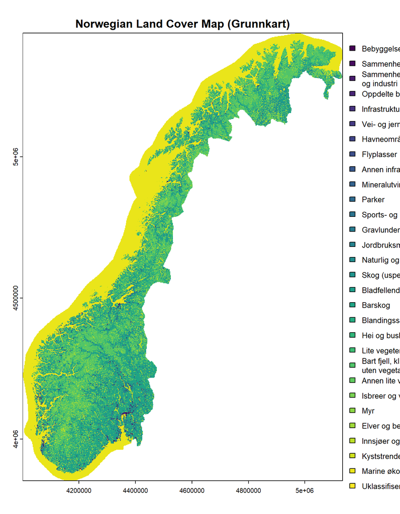

```r
gc()
# read Norway Grunnkart (this is our reference LCM) ----------------------------
lcm<-terra::rast(file.path(dfp,"Norway_files","Grunnkart","Grunnkart_OT.tif"))
terra::plot(lcm, main="Norwegian Land Cover Map (Grunnkart)")
```

Now the fact of the matter is that the categories used in the Norwegian LCM do not perfectly correspond to the categories used in the curve number table. Therefore we first need to translate the Norwegian categories into the system used in the CORINE data. Note we treat the sea as NA because it is not relevant for flood control.

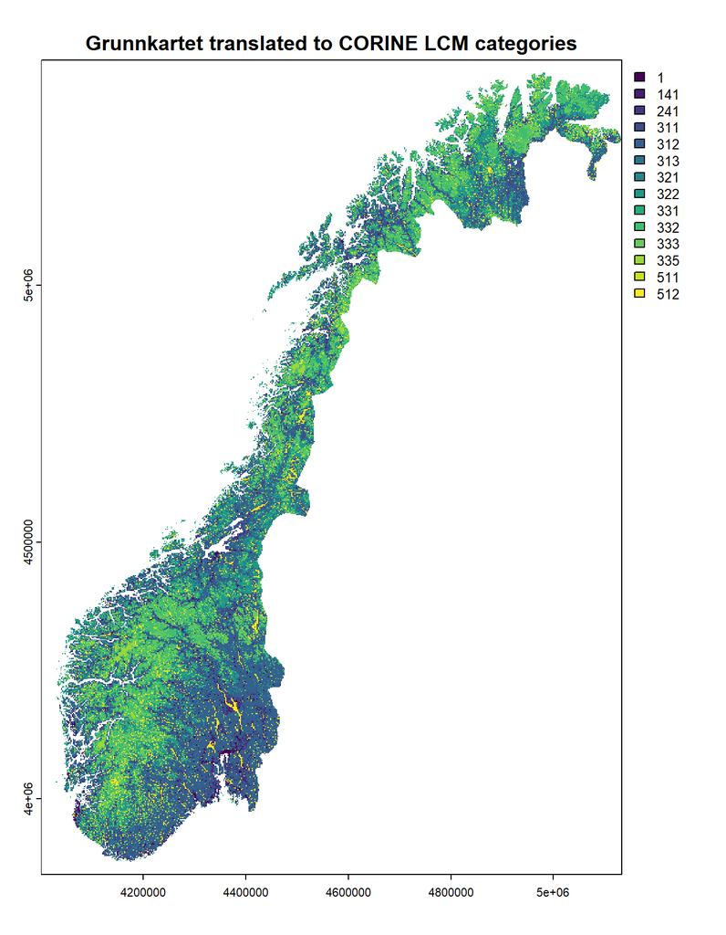

```r
gc()
# make a numeric version of the lcm --------------------------------------------
lcm2<-lcm
activeCat(lcm2) <- "Value"
lcm2<-as.numeric(lcm2)
# read in grunnkart lookup -----------------------------------------------------
lcm_idf<-read.csv(file.path(dfp,"Norway_files","Grunnkart",
                            "Lookup_grunnkart.csv"))
# read in curve number table ---------------------------------------------------
cn_idf<-read.csv(file.path(dfp,"version_2_2","inca_input_floodcontrol",
                           "Lookup_tables",
                           "curve_number_per_landcover_soil.csv"))
# adjust lcm to feature official CORINE categories -----------------------------
# (otherwise our CN lookup table does not fit)
# I create this concordance using the following sources
# https://land.copernicus.eu/content/corine-land-cover-nomenclature-guidelines/html/
# https://nibio.brage.unit.no/nibio-xmlui/bitstream/handle/11250/3120510/NIBIO_RAPPORT_2024_10_28.pdf?sequence=1&isAllowed=y
lcm_idf['CN_cover_id']<-NA
lcm_idf$CN_cover_id[lcm_idf$landcover_id %in%
                      c(100,111,112,121,130,131,132,133,134,135,142,152)] <- 1
lcm_idf$CN_cover_id[lcm_idf$landcover_id == 141] <- 141
lcm_idf$CN_cover_id[lcm_idf$landcover_id == 200] <- 241
lcm_idf$CN_cover_id[lcm_idf$landcover_id == 310] <- 231
lcm_idf$CN_cover_id[lcm_idf$landcover_id == 320] <- 321
lcm_idf$CN_cover_id[lcm_idf$landcover_id == 400] <- 312
lcm_idf$CN_cover_id[lcm_idf$landcover_id == 410] <- 311
lcm_idf$CN_cover_id[lcm_idf$landcover_id == 420] <- 312
lcm_idf$CN_cover_id[lcm_idf$landcover_id == 440] <- 313
lcm_idf$CN_cover_id[lcm_idf$landcover_id == 520] <- 322
lcm_idf$CN_cover_id[lcm_idf$landcover_id == 600] <- 333
lcm_idf$CN_cover_id[lcm_idf$landcover_id == 611] <- 332
lcm_idf$CN_cover_id[lcm_idf$landcover_id == 623] <- 333
lcm_idf$CN_cover_id[lcm_idf$landcover_id == 631] <- 335 # NA in CN lookup
lcm_idf$CN_cover_id[lcm_idf$landcover_id == 720] <- 322
lcm_idf$CN_cover_id[lcm_idf$landcover_id == 810] <- 511 # NA in cn lookup
lcm_idf$CN_cover_id[lcm_idf$landcover_id == 910] <- 512 # NA in cn lookup
lcm_idf$CN_cover_id[lcm_idf$landcover_id == 1100] <- 331 # NA in cn lookup
lcm_idf$CN_cover_id[lcm_idf$landcover_id == 1200] <- NA # NA 523 in cn lookup
# and then we add the last category that is not available (uklassifisert)
lcm_idf <- rbind(lcm_idf,c(NA,9900,"unclassified","uklassifisert",NA))
lcm_idf$landcover_id <- as.numeric(lcm_idf$landcover_id)
# make a new lcm that features the CN_cover_id
lcm3 <- terra::subst(lcm2,lcm_idf$landcover_id,lcm_idf$CN_cover_id)
terra::plot(lcm3, main="Grunnkartet translated to CORINE LCM categories")
```

```r
# make a numeric version of this
lcm4 <- rast(ext(lcm3),resolution=res(lcm3),crs=crs(lcm3))
values(lcm4)<-as.numeric(extr_lvl_from_raster_lyr(lcm3,"value"))
gc()
```

So this is our reference land cover map. Moving on.

### 3.2.2 Hydrological Soil Type

We use the INCA default hydrological soil type map and a few adjustments are required here. First we need to mask it to our reference LCM. Then we need to figure out what we do with the part in northern Norway that is missing in the data.

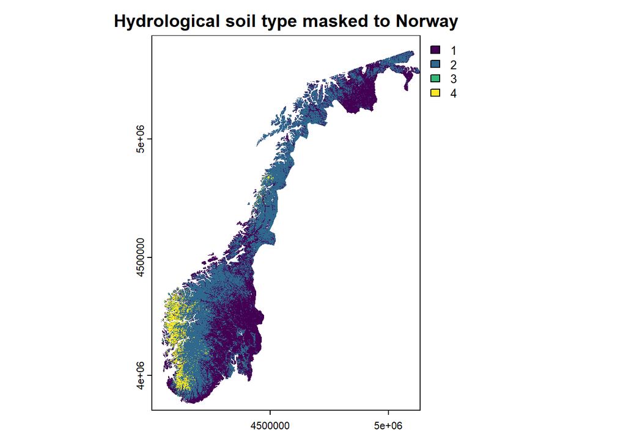

```r
# read hydrological soil type map ----------------------------------------------
soils<-terra::rast(file.path(dfp,"version_2_2","inca_input_floodcontrol",
                             "Hydrological_soil_type_map",
                             "hydro_soilgroup_INCA_EPSG3035.tif"))
# mm comment: only four categories seems a bit coarse...
# mm comment: the soils data is masked in a weird way in the north of Norway.
# I think we should really use something better here.
# first crop and mask soils ----------------------------------------------------
soils<-crop(soils,lcm)
soils<-mask(soils,lcm)
terra::plot(soils, main="Hydrological soil type masked to Norway")
```

```r
# mm comment: so here you see again how the soil map is weirdly masked in the
# north. comes from the input data. To be sorted out later
```

Here is my suggested quick fix (which we could revisit later): We just define the missing data cells as hydrological soil type 2. This is the most common hydrological soil type in Norway.

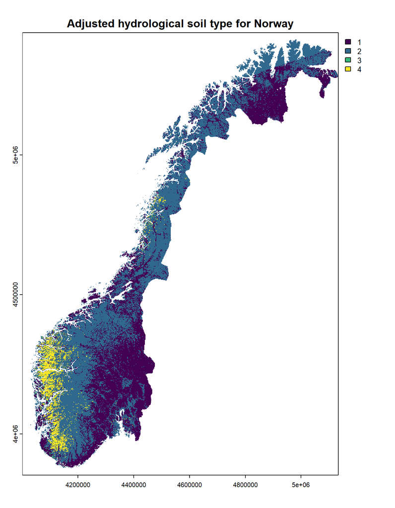

```r
gc()
soils[is.na(soils)]<-2
soils<-mask(soils,lcm3)
terra::plot(soils, main="Adjusted hydrological soil type for Norway")
```

Ok this is better.

### 2.2.3 Curve Number

So this is now basically a lookup exercise. My approach is to vectorise the rasters, then run the merge process, then rasterise again. There are probably more efficient ways to do this, but this one is simple and it seems to work.

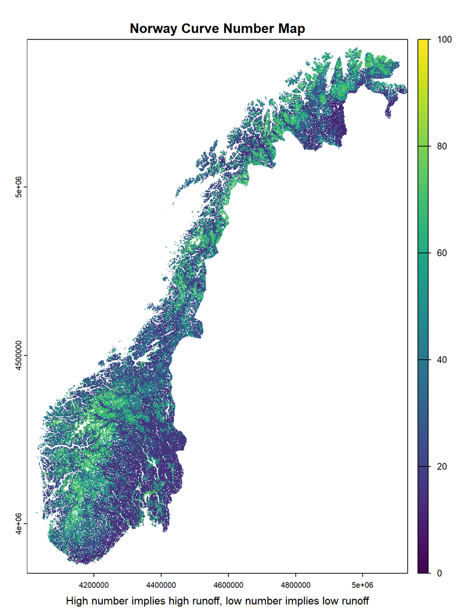

```r
gc()
# extract data vectors
lcmv <-extr_lvl_from_raster_lyr(lcm3,"value")
soilsv <-extr_lvl_from_raster_lyr(soils,"hydro_soilgroup_INCA_EPSG3035")
# put into a dataframe
dfc<-as.data.frame(matrix(NA,nrow=length(lcmv),ncol=2))
colnames(dfc)<-c("lcmd","soilsd")
dfc$lcmd <- as.numeric(lcmv)
dfc$soilsd <- soilsv
# join with CN lookup table
dfc <- dfc %>% left_join(cn_idf,by = join_by(lcmd == landcover_id,soilsd == Soil))
# then make a raster from the vector
cnm <- rast(ext(lcm3),resolution=res(lcm3),crs=crs(lcm3))
values(cnm)<-dfc$CN
# plot result
terra::plot(cnm, range=c(0,100), main="Norway Curve Number Map", sub="High number implies high runoff, low number implies low runoff")
```

```r
# clean up ---------------------------------------------------------------------
rm(dfc,soils,lcmv,soilsv)
gc()
```

Note the map has a quite a few holes, and this comes from cells that have no CN number in the lookup table. Revisit later. The categories in question are: 9900 (uklassifisert, 1200 (marine økosystemer (uspesifisert)), 1100 (Kyststrender dyner og våtmark (uspesifisert)), 910 (Innsjøer og dammer), 810 (Elver og bekker), and 631 (Isbreer og varige snøfonner). We might want to consider making a modification later so that we assume some CN for some of these categories, i.e. 1100 (CORINE category 331) and 631 (CORINE category 335). Could for example check how Switzerland treats their glacier land cover. Assuming no CN implies that these cells cannot provide flood control.

## 3.3 CN Map Modification

In the following subsections we make adjustments to the curve number map so it becomes more nuanced. We do this by following the process described in the guidance note. In some cases the equations from the guidance note are faulty, for example, plus and minus signs are mixed up. These faults have been identified and correctd by Statistics Ireland and we follow the corrected version.

### 3.3.1 Imperviousness Correction

We use the INCA default impervious density map, masked to our reference raster.

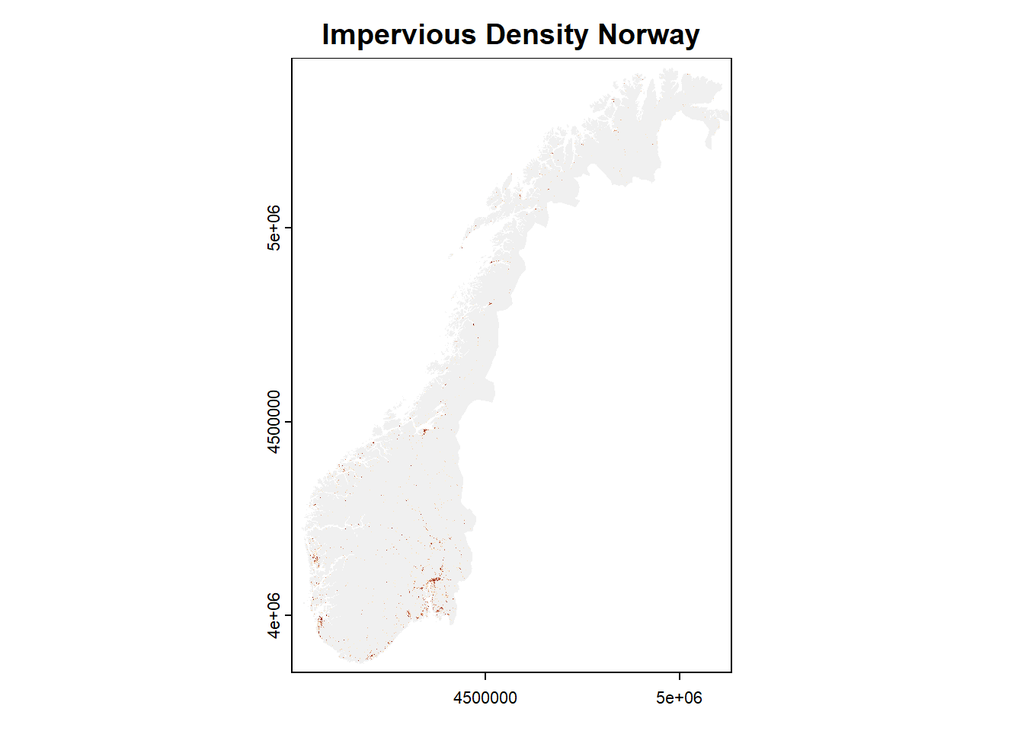

```r
imp <- terra::rast(file.path(dfp,"version_2_2","inca_input_floodcontrol",
                             "Impervious_density_map",
                             "IMD_2018_100m_eu_03035_V2_0_INCA_100m_EPSG3035.tif"))
# first crop and mask to Norway
imp<-crop(imp,lcm)
imp<-mask(imp,lcm)
terra::plot(imp, main="Impervious Density Norway")
```

The modification process for imperviousness follows an equation that comes from the guidance note. Impervious density is given as an index between 0 and 100. The process basically increases the CN number in areas where the ground is impervious (where it does not easily absorb water). We implement this straight with the rasters, and then plot the result. Differences are small and mostly visible in cities. Here zooming in on the Oslo area.

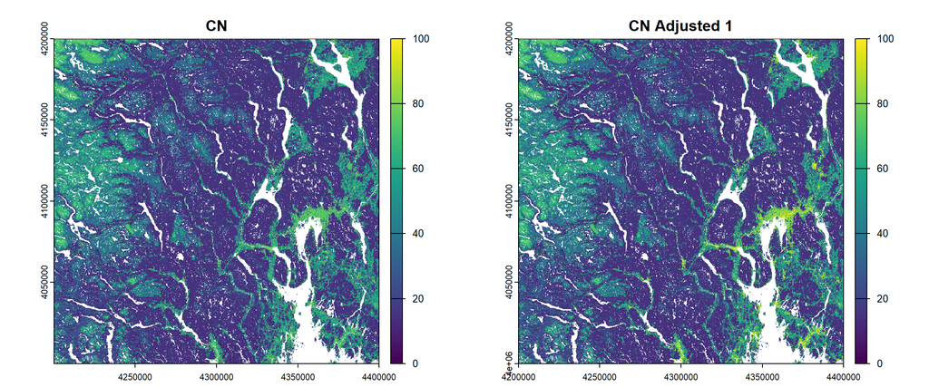

```r
cnmi <- 98*(imp/100) + (1-(imp/100))*cnm
# make a stack
cnm1 <- c(cnm,cnmi)
names(cnm1)<-c("CN","CN Adjusted 1")
# plot for Oslo area
terra::plot(cnm1,range=c(0,100),ext = c(4200000,4400000,4000000,4200000))
```

```r
# clean up
rm(imp,cnmi,cnm)
gc()
```

### 3.3.2 Slope Correction

We use the INCA default DEM and Slope maps, cropped and masked to Norway. The modification process again follows an equation provided in the guidance note. Here first a plot of slopes. Note: 100% slope means 45 degrees incline, 200% slope means 63.4 degrees incline, Inf % slope means 90 degrees incline.

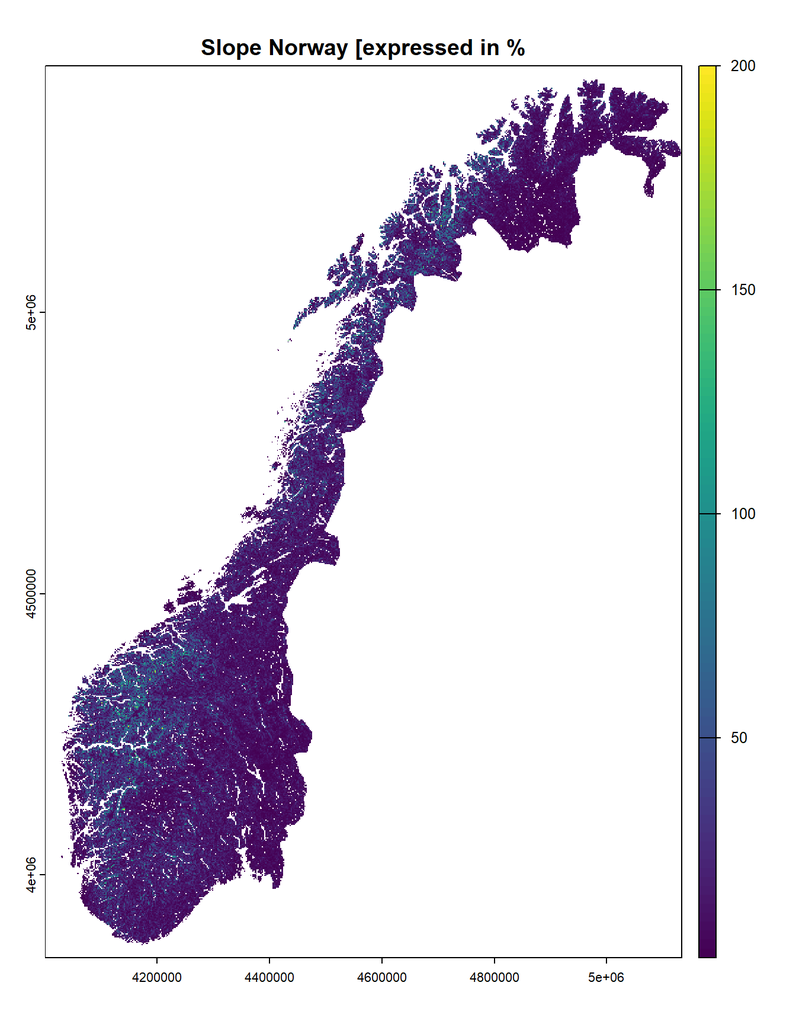

```r
slop <- terra::rast(file.path(dfp,"version_2_2","inca_input_floodcontrol",
                             "DEM_and_Slope_maps",
                             "dt1_slope_INCA_EPSG3035_100m_Byte.tif"))
slop<-crop(slop,lcm)
slop<-mask(slop,lcm)
plot(slop, main="Slope Norway [expressed in %")
```

Our data provides slopes in percent. The equation stated in the guidance note based on Huang et al 2016 requires slopes as ratio (ratio = percent/100). Zero slope is NA in the data, so I first turn all NA to zero before running the process. Then apply the formula as stated in the guidance note. Note: This adjustment process increases the CN number for cells that have a steep slope. Finally, we make a plot to see what difference the operation makes. All in all the differences are very small and we need to zoom in a lot to see anything. The example area provided below is close to Åndalsnes.

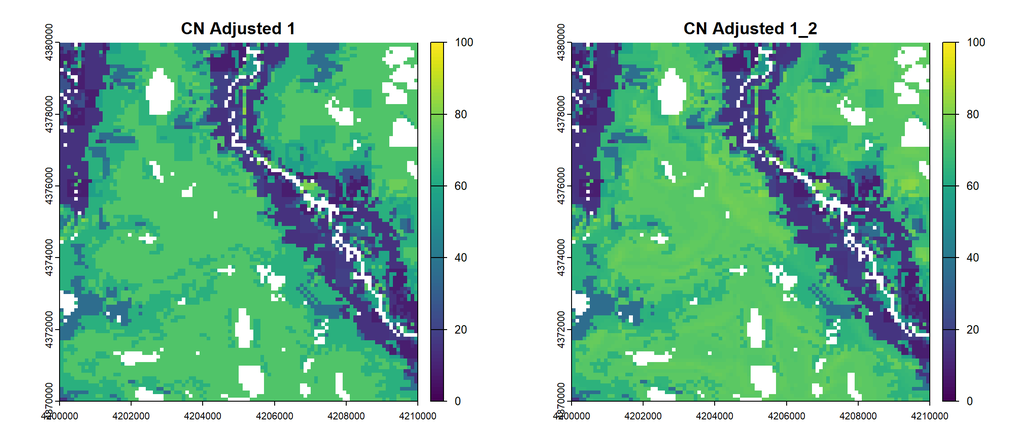

```r
slop[is.na(slop)]<-0
cnma <- cnm1[['CN Adjusted 1']] * ((322.79 + (15.63*slop/100))/((slop/100)+323.52))
cnm2<-c(cnm1,cnma)
names(cnm2)<-c("CN","CN Adjusted 1","CN Adjusted 1_2")
plot(cnm2[[c(2,3)]],range=c(0,100),ext = c(4200000,4210000,4370000,4380000))
```

```r
rm(slop,cnma,cnm1)
gc()
```

### 3.3.3 Riparian Zone Correction

The last adjustment is made for riparian zones. Again we use INCA default data for this adjustment and we follow the process decribed in the guidance note. Here a plot of riparian zones in Norway.

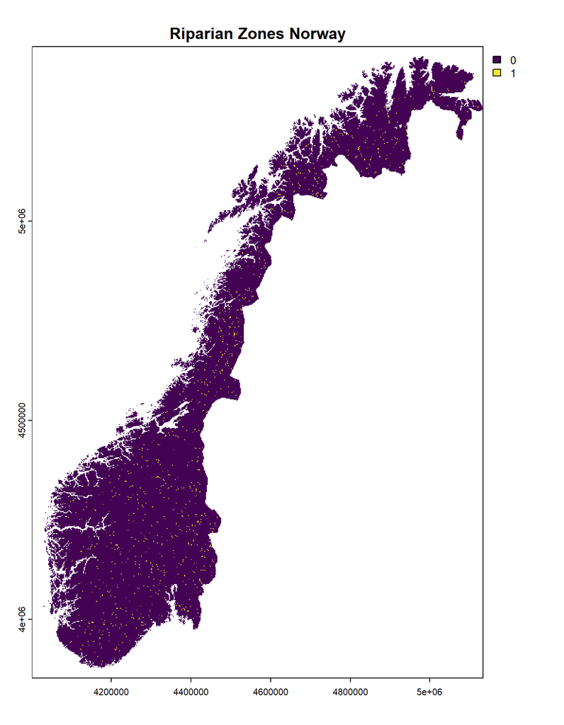

```r
# import data
rip <- terra::rast(file.path(dfp,"version_2_2","inca_input_floodcontrol",
                              "Riparian_zones_map",
                              "RiparianZonesEU_INCA_EPSG3035.tif"))


# first crop and mask to Norway
rip<-crop(rip,lcm)
rip<-mask(rip,lcm)
# to make it better visible
rip[is.na(rip) & !is.na(lcm3)]<-0
# plot
plot(rip,main="Riparian Zones Norway")
```

And then the process. It is quite straightforward: If a cell is part of a riparian zone, it receives the lowest possible CN value that exists for the land cover category. So it basically saying: All cells that are riparian zones have hydrological soil type 1 (see section 3.2.2). The process therefore reduces the CN numbers in riparian zones, but it does not change the CN map by much. Below a plot zooming in on where Svelle (Øyeren/Glomma) flows into Nitelva (passing Lillestrøm).

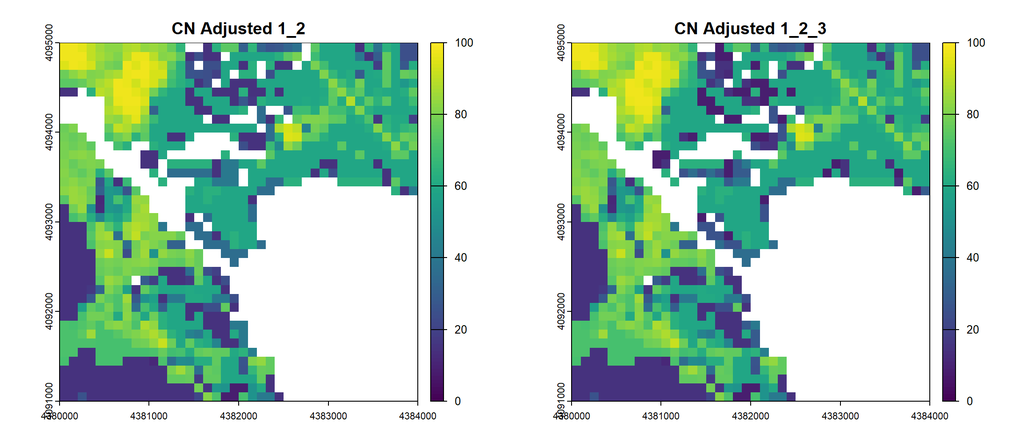

```r
# define relevant landcover categories as per guidance note
lcm_idf['rip_relevant']<-0
relevant_codes <- c(244,311,312,313,321,322,323,324,411,412,421,422,423)
# mm note: most of those do not exist in our Grunnkart in Norway...
# the only ones in Norway are category 3 (forest)
lcm_idf$rip_relevant[lcm_idf$CN_cover_id %in% relevant_codes]<-1
# now for those cells where we are in a relevant riparian zone we will attribute
# the lowest possible cn number for the respective land cover.
# get vector of rip
ripv <- extr_lvl_from_raster_lyr(rip,"RiparianZonesEU_INCA_EPSG3035")
# get vector of lcm
lcmv <- extr_lvl_from_raster_lyr(lcm3,"value")
lcmv <-as.numeric(lcmv)
# get vector of CN
cnv <- extr_lvl_from_raster_lyr(cnm2,"CN Adjusted 1_2")
# relevant rip lcmv
dfc<-as.data.frame(matrix(NA,ncol=3,nrow=length(lcmv)))
colnames(dfc)<-c("lcm","rip","relevant")
#first the land cover data
dfc$lcm <- lcmv
#then the riparian zone data
dfc$rip <- ripv
# then the relevant cells
dfc$relevant[dfc$rip==1 & dfc$lcm %in% relevant_codes] <- 1
# then find the lowest possible CN value for each cell
dfc <- dfc %>%
  left_join(cn_idf %>% filter(Soil==1) %>% select(-Soil),by = join_by(lcm == landcover_id)) %>%
  rename(CN1 = CN)
#clean up
rm(rip,ripv,lcmv)
dfc <- dfc %>% select(-c(lcm,rip))
gc()
#then get the cn number for each cell
dfc['CNIS'] <- cnv
rm(cnv)
#adjusted CN is the lowest CN
dfc['CNISR'] <- dfc$CN1
gc()
# apart from in rip-irrelevant cells, where it is the old CN value
dfc$CNISR[is.na(dfc$relevant)] <- dfc$CNIS[is.na(dfc$relevant)]
gc()
# then make a new raster
cnma <- rast(ext(lcm3),resolution=res(lcm3),crs=crs(lcm3))
values(cnma)<-dfc$CNISR
names(cnma)<-c("CN Adjusted 1_2_3")
# then stack with our other
cnm2 <- c(cnm2,cnma)
# and plot where we can see something
plot(cnm2[[c(3,4)]],range=c(0,100),ext = c(4380000,4384000,4091000,4095000))
```

```r
# clean up
rm(dfc,relevant_codes,cnma)
gc()
```

That was it for adjustments. The exercise might be more precise if we could get hold of more detailed and specific data for Norway.

## 2.4 Runoff Retention Map

We just need to reverse the scale of the CN map for this. So that a high number implies that water is absorbed, and a low number implies that water is not absorbed. This is now the main map from which we derive flood control service provision.

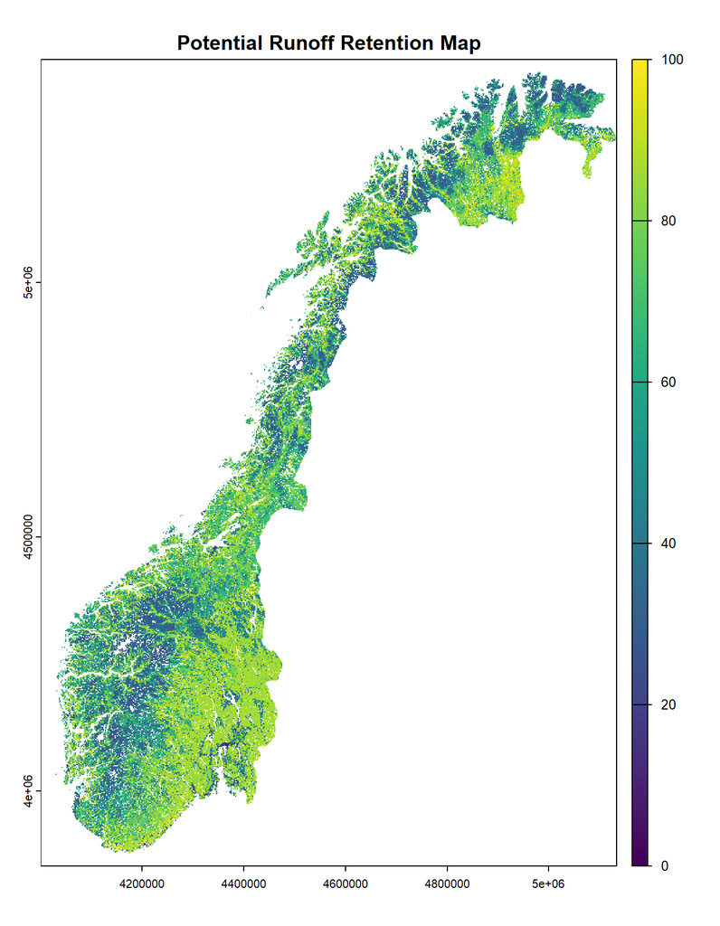

```r
# identify max value
max_value <- as.numeric(global(cnm2[[4]],fun = "max", na.rm=T))
# create map
potm <- max_value - cnm2[[4]]
names(potm)<-"Pot_Runuff_Retention"
# save
writeRaster(potm,file.path(rfp,"runoff_retention.tif"),overwrite=T)
# plot
plot(potm, range=c(0,100),main = "Potential Runoff Retention Map")
```

```r
# clean up
rm(max_value)
gc()
```

## 3.5 SPA Thresholds

So now based on our potential runoff retention map we define our service providing areas (SPA). There are three different ones, depending on whether the areas are located on urban/artificial land, agricultural land, or natural land. SP areas are binary, so 1/0. In order to define them, we use runoff retention thresholds, one for each parent land category. If a cell has a runoff retention value that is at least as large as the threshold, it is defined as service providing cell. This means that it provides the service of flood control, because it retains water.

Harry at Statistics Ireland came up with their own thresholds, calculated the same way as the EU guidance note suggests. For our version I have first tried to use the thresholds that the guidance note suggests for Europe (27 for artificial land, 52 for agricultural land, 61 for natural land), but then found that these may not be so applicable for Norway. One problem was, for example, that none of the Norwegian agricultural land could be classified as flood control service providing area, simply because the runoff retention threshold of 52 is too high (there is no agricultural patch in Norway that exceeds this threshold). It might be that Norwegian agricultural land is more impervious than EU average agricultural land. If we went with EU thresholds, then no Norwegian agricultural land could provide flood control.

MM: I see the point of incorporating standard variation in the formula to calculate the thresholds, because this avoids inflated threholds when outliers inflate the mean, and it accounts for heterogeneity. Other than that, however, I am not sure whether this threshold-based definition of service provision comes with desirable properties. I suggest to discuss this further and check other sources than the EU guidance note.

```r
## first on artificial
artif_id<-c(1,141)
spam_artif_am <- rast(ext(lcm3),resolution=res(lcm3),crs=crs(lcm3))
spam_artif_am[[1]]<-0
spam_artif_am[is.na(lcm3)]<-NA
for(i in 1:length(artif_id)){
  spam_artif_am[lcm4 == artif_id[i]]<-mean(potm[lcm4 == artif_id[i]],na.rm=T) + sd(potm[lcm4 == artif_id[i]],na.rm=T)
}
spa_tld_artif <- mean(spam_artif_am[lcm4 %in% artif_id],na.rm=T)
## then on agricultural
agric_id<-c(241,231)
spam_agric_am <- rast(ext(lcm3),resolution=res(lcm3),crs=crs(lcm3))
spam_agric_am[[1]]<-0
spam_agric_am[is.na(lcm3)]<-NA
for(i in 1:length(agric_id)){
  spam_agric_am[lcm4 == agric_id[i]]<-mean(potm[lcm4 == agric_id[i]],na.rm=T) + sd(potm[lcm4 == agric_id[i]],na.rm=T)
}
spa_tld_agric <- mean(spam_agric_am[lcm4 %in% agric_id],na.rm=T)
## then on natural
natur_id<-c(321,312,311,313,322,333,332)
spam_natur_am <- rast(ext(lcm3),resolution=res(lcm3),crs=crs(lcm3))
spam_natur_am[[1]]<-0
spam_natur_am[is.na(lcm3)]<-NA
for(i in 1:length(natur_id)){
  spam_natur_am[lcm4 == natur_id[i]]<-mean(potm[lcm4 == natur_id[i]],na.rm=T) - sd(potm[lcm4 == natur_id[i]],na.rm=T)
}
spa_tld_natur <- mean(spam_natur_am[lcm4 %in% natur_id],na.rm=T)
## clean up
rm(spam_artif_am,spam_agric_am,spam_natur_am)
gc()
```

Here are the thresholds.

```r
# print thresholds
print(paste("Artificial tld:",spa_tld_artif))
```

```
## [1] "Artificial tld: 30.8893698069349"
```

```r
print(paste("Agricultural tld:",spa_tld_agric))
```

```
## [1] "Agricultural tld: 48.8282508850098"
```

```r
print(paste("Natural tld:",spa_tld_natur))
```

```
## [1] "Natural tld: 61.3397302555812"
```

## 3.6 SPA Maps

Now given our thresholds we make a stack of maps for the SPAs

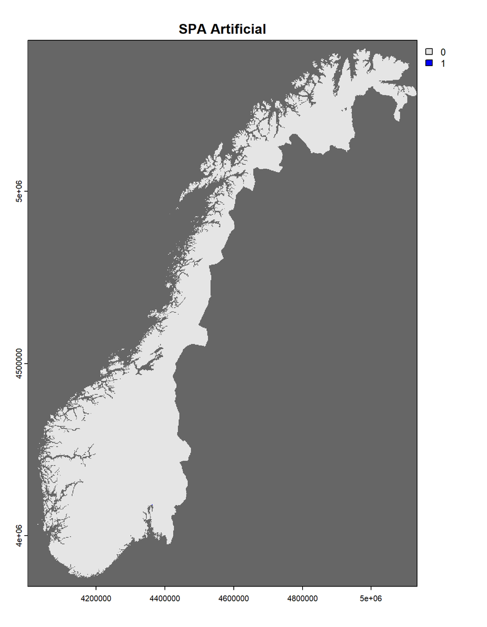

```r
# Artificial spa
spam_artif<-rast(ext(lcm3),resolution=res(lcm3),crs=crs(lcm3))
spam_artif[[1]]<-0
spam_artif[is.na(lcm3)]<-NA
spam_artif[lcm4 %in% artif_id & potm >= spa_tld_artif] <-1
# Agricultural spa
spam_agric<-rast(ext(lcm3),resolution=res(lcm3),crs=crs(lcm3))
spam_agric[[1]]<-0
spam_agric[is.na(lcm3)]<-NA
spam_agric[lcm4 %in% agric_id & potm >= spa_tld_agric] <-1
# Natural spa
spam_natur<-rast(ext(lcm3),resolution=res(lcm3),crs=crs(lcm3))
spam_natur[[1]]<-0
spam_natur[is.na(lcm3)]<-NA
spam_natur[lcm4 %in% natur_id & potm >= spa_tld_natur] <-1
# write raster
writeRaster(spam_artif,file.path(rfp,"spam_artif.tif"),overwrite=T)
writeRaster(spam_agric,file.path(rfp,"spam_agric.tif"),overwrite=T)
writeRaster(spam_natur,file.path(rfp,"spam_natur.tif"),overwrite=T)
# stack together and plot
spam <-c(spam_artif,spam_agric,spam_natur)
names(spam)<-c("SPA Artificial","SPA Agricultural", "SPA Natural")
ccspam<-data.frame(value=c(0,1),col=c("grey90","blue"))
plot(spam[[1]],col=ccspam,colNA="grey40",main = "SPA Artificial")
```

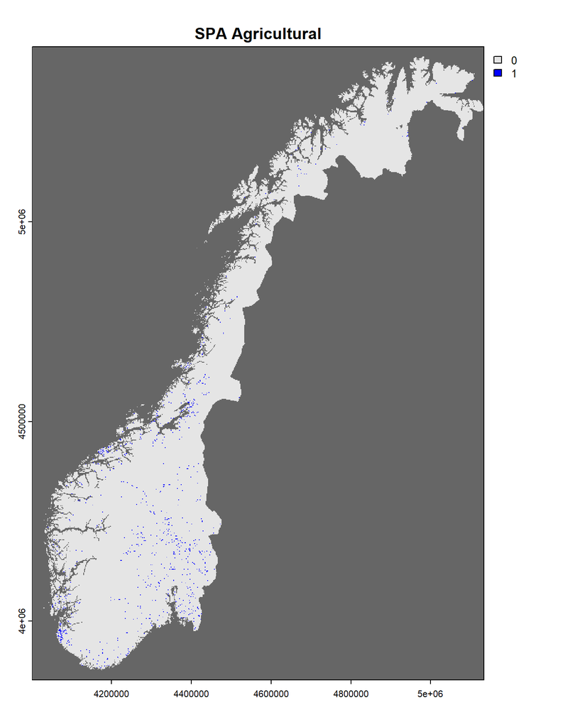

```r
plot(spam[[2]],col=ccspam,colNA="grey40",main = "SPA Agricultural")
```

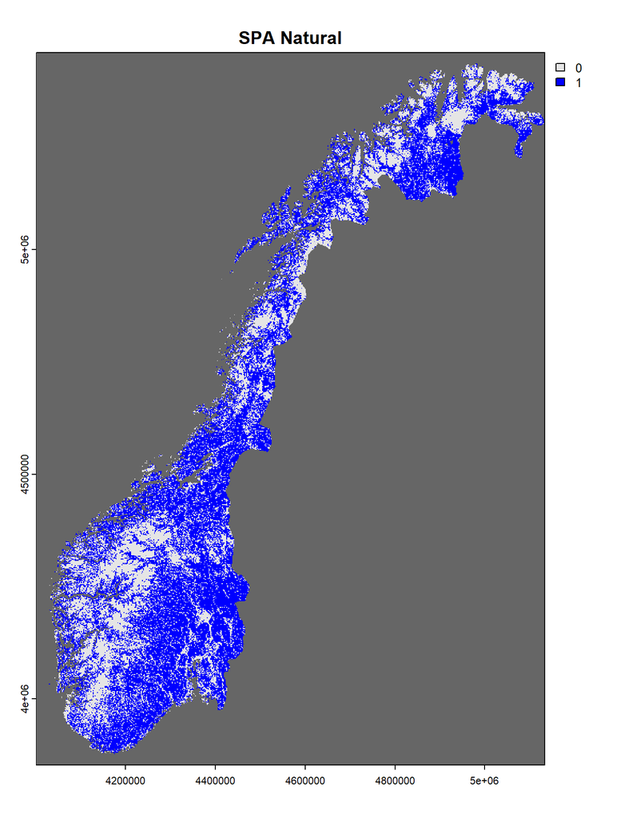

```r
plot(spam[[3]],col=ccspam,colNA="grey40",main = "SPA Natural")
```

```r
# clean up
rm(ccspam,spam_artif,spam_agric,spam_natur,potm)
gc()
```

# 4. Service Demanding Areas (SDA)

## 4.1 Calculation and Results

SDAs are service demanding areas. These are defined as economic assets located in flood risk areas. Formally: total spatial extent of economic assets that are located in an area which NVE defines as “aktsomhetsområde”. Our definition differs from the EU definition, in that we use flood risk areas, whereas the EU uses areas that get flooded at least once within a specific horizon of time. The second kind of service demanding areas are total amount of population inhabiting flood risk areas.

So first, we start reading in the data and making it fit to our reference map. Note that the original NVE flood risk map is a vector file. We first rasterise this file to our default grid, and we do this outside of this markdown script because it is a time-intensive operation. The rasterisation algorithm defines cells as flood risk areas if their center is within a flood risk vector shape.

Here are our flood risk areas.

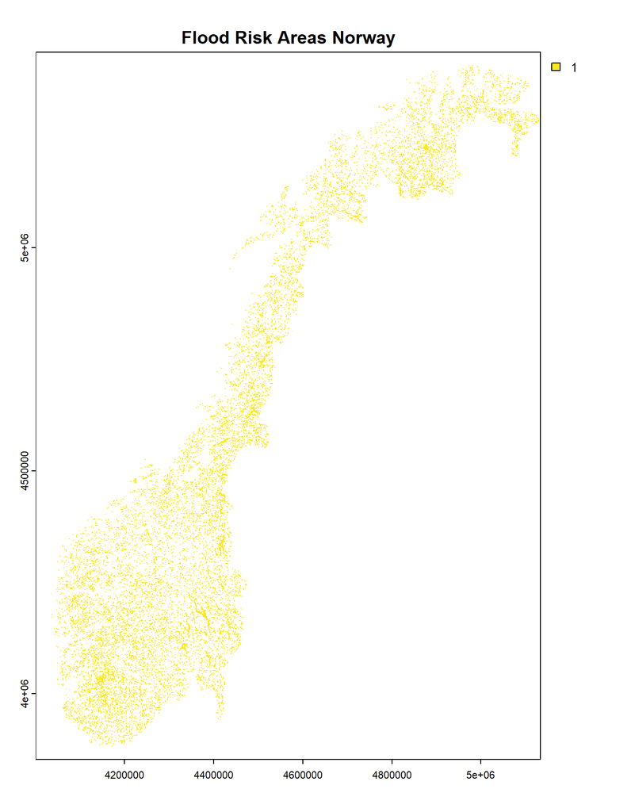

```r
# population
popr<-rast(file.path(dfp,"population","Mollweide","GHS_POP_E2020_GLOBE_R2023A_54009_100_V1_0.tif"))
popr<-crop(popr,ext(250000,
                    2000000,
                    6600000,
                    8000000) # 8700000 if svalbard included
                    )
popr <- terra::project(popr,lcm,mask=T)

# flood
flood <- terra::rast(file.path(dfp,"Norway_files","NVE_flom","NVEKartdata",
                                     "NVEData","Flom_Aktsomhet",
                                     "Flom_AktsomhetOmr_form.tif"))
plot(flood, main = "Flood Risk Areas Norway")
```

```r
gc()
```

Now it is literally just a question of identifying cells in the flood areas. And then plot results.

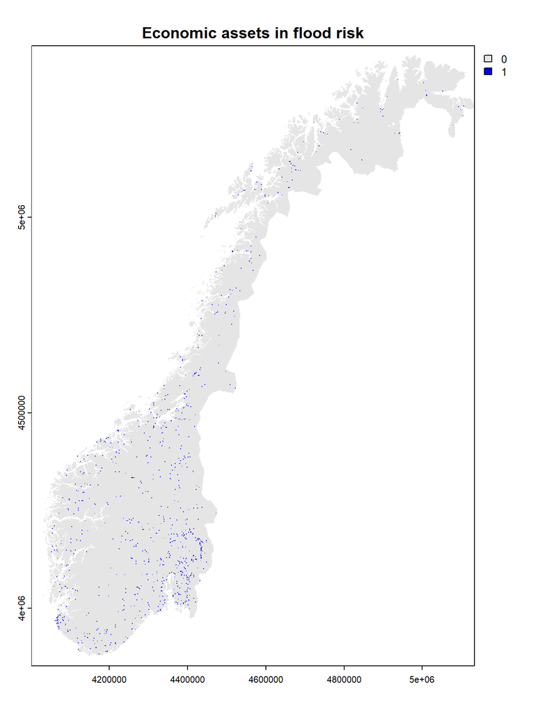

```r
# service demand by population
sdam_pop <- rast(ext(lcm3),resolution=res(lcm3),crs=crs(lcm3))
sdam_pop[[1]] <- 0
sdam_pop[is.na(lcm3)]<-NA
sdam_pop[flood == 1 & popr>0] <- popr[flood == 1 & popr>0]
# service demand by artificial land
sdam_artif <- rast(ext(lcm3),resolution=res(lcm3),crs=crs(lcm3))
sdam_artif[[1]] <- 0
sdam_artif[is.na(lcm3)]<-NA
sdam_artif[flood == 1 & lcm4 %in% artif_id] <- 1
# service demand by agricultural land
sdam_agric <- rast(ext(lcm3),resolution=res(lcm3),crs=crs(lcm3))
sdam_agric[[1]] <- 0
sdam_agric[is.na(lcm3)]<-NA
sdam_agric[flood == 1 & lcm4 %in% agric_id] <- 1
# aggregate to economic assets
sdam_econ <- sdam_artif + sdam_agric
# save
writeRaster(sdam_pop,file.path(rfp,"sdam_pop.tif"),overwrite=T)
writeRaster(sdam_econ,file.path(rfp,"sdam_econ.tif"),overwrite=T)
# plot
plot(sdam_econ,col=c("grey90","blue"),main = "Economic assets in flood risk")
```

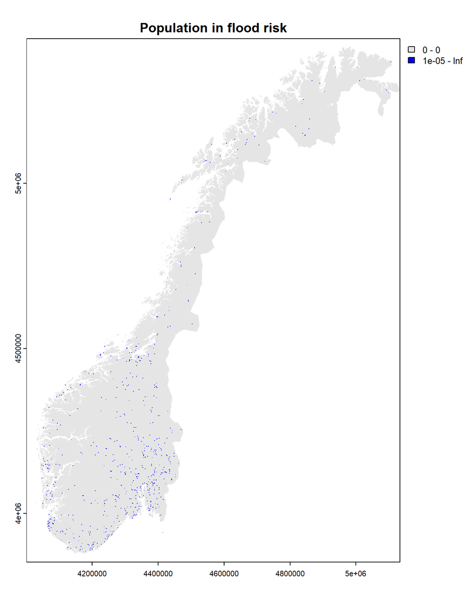

```r
ccsdam<-data.frame(from=c(0,0.00001),to=c(0,Inf),col=c("grey90","blue"))
plot(sdam_pop,col=ccsdam, main = "Population in flood risk")
```

```r
#clean up
rm(lcm3,lcm4,popr,flood,ccsdam)
gc()
```

Important to note for the next sections: “Economic assets” are defined as cells that are either agricultural land or artificial land. So we add two service demand categories together for this.

## 4.2 Plots for KS Project

First we need to import all KS shapefiles and street data.

```r
ahs<-terra::vect(file.path(dfp,"Norway_files","Aurskog","aurskog.shp"))
ahr<-terra::vect(file.path(dfp,"Norway_files","ks_formatted_shapes_wosm","ahr.shp"))
ehs<-terra::vect(file.path(dfp,"Norway_files","Evje","evje_formatted.shp"))
ehr<-terra::vect(file.path(dfp,"Norway_files","ks_formatted_shapes_wosm","ehr.shp"))
hos<-terra::vect(file.path(dfp,"Norway_files","Holtalen","holtalen.shp"))
hor<-terra::vect(file.path(dfp,"Norway_files","ks_formatted_shapes_wosm","hor.shp"))
mos<-terra::vect(file.path(dfp,"Norway_files","Moss","moss.shp"))
mor<-terra::vect(file.path(dfp,"Norway_files","ks_formatted_shapes_wosm","mor.shp"))
nrs<-terra::vect(file.path(dfp,"Norway_files","Nordreisa","nordreisa.shp"))
nrr<-terra::vect(file.path(dfp,"Norway_files","ks_formatted_shapes_wosm","nrr.shp"))
sds<-terra::vect(file.path(dfp,"Norway_files","Stad","stad.shp"))
sdr<-terra::vect(file.path(dfp,"Norway_files","ks_formatted_shapes_wosm","sdr.shp"))
vrs<-terra::vect(file.path(dfp,"Norway_files","Vardo","vardo.shp"))
vrr<-terra::vect(file.path(dfp,"Norway_files","ks_formatted_shapes_wosm","vrr.shp"))
vas<-terra::vect(file.path(dfp,"Norway_files","Vaagan","vaagan.shp"))
var<-terra::vect(file.path(dfp,"Norway_files","ks_formatted_shapes_wosm","var.shp"))
gc()
```

And then let’s plot service demand for our case studies.

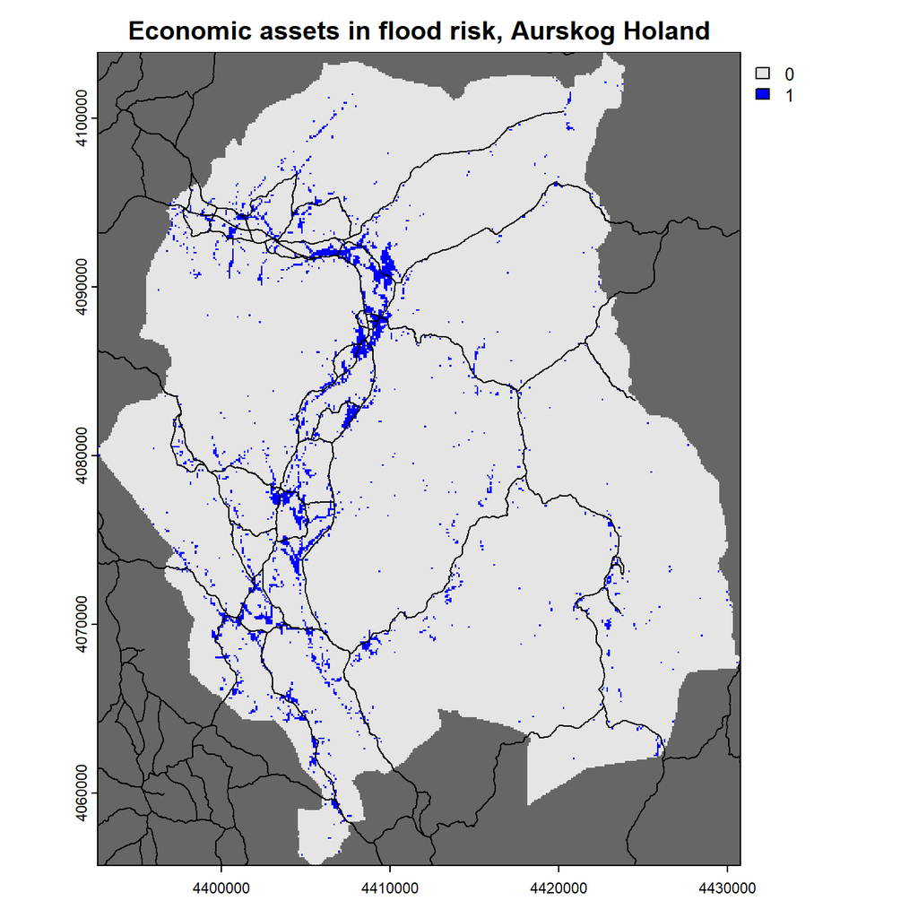

```r
# colour code
ccsdam<-data.frame(value=c(0,1),col=c("grey90","blue"))
# Aurskog Høland
plot(sdam_econ %>% crop(ahs,mask=T),col=ccsdam,colNA="grey40",
     main="Economic assets in flood risk, Aurskog Holand")
plot(ahr,add=T)
```

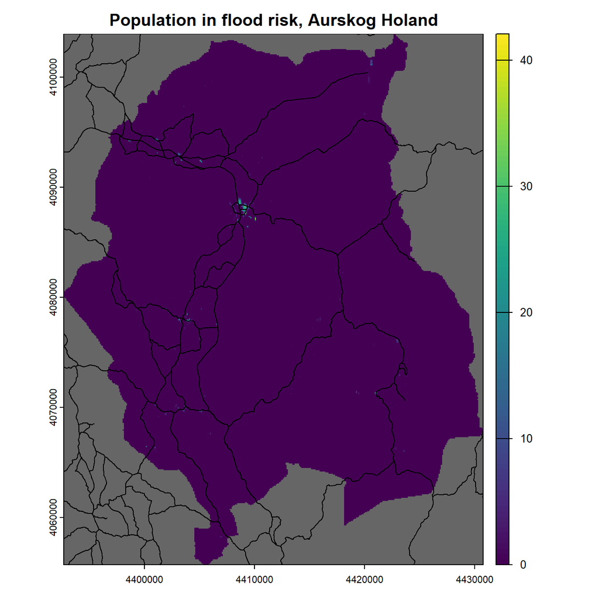

```r
plot(sdam_pop %>% crop(ahs,mask=T),colNA="grey40",
     main="Population in flood risk, Aurskog Holand")
plot(ahr,add=T)
```

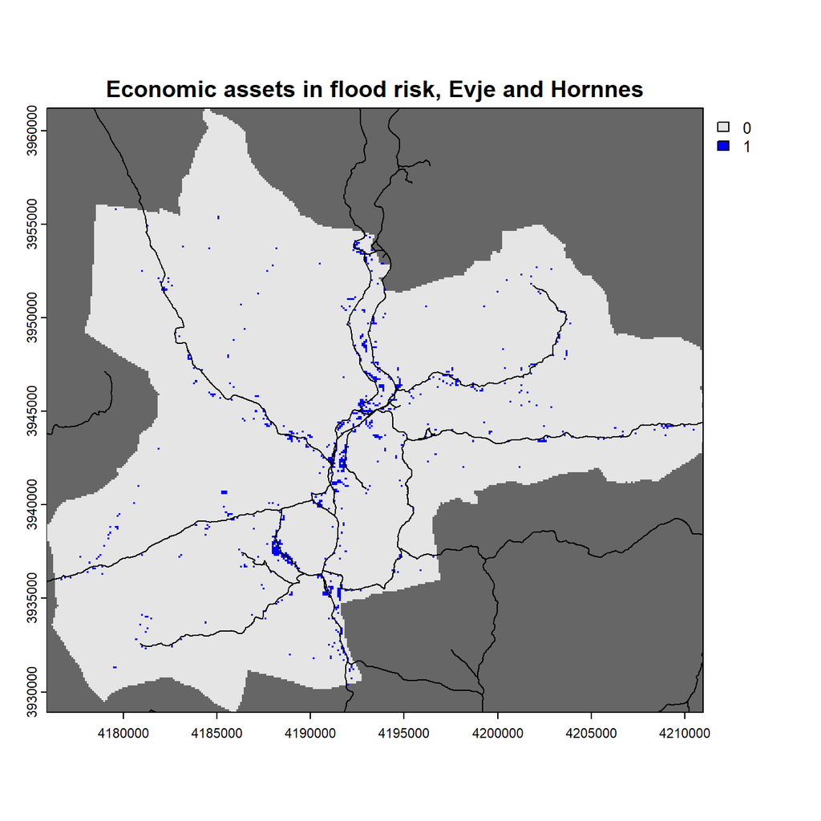

```r
# Evje and Hornnes
plot(sdam_econ %>% crop(ehs,mask=T),col=ccsdam,colNA="grey40",
     main="Economic assets in flood risk, Evje and Hornnes")
plot(ehr,add=T)
```

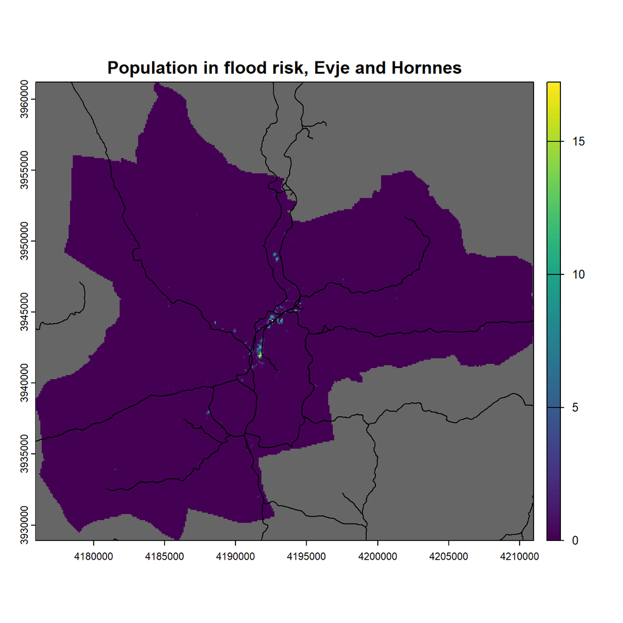

```r
plot(sdam_pop %>% crop(ehs,mask=T),colNA="grey40",
     main="Population in flood risk, Evje and Hornnes")
plot(ehr,add=T)
```

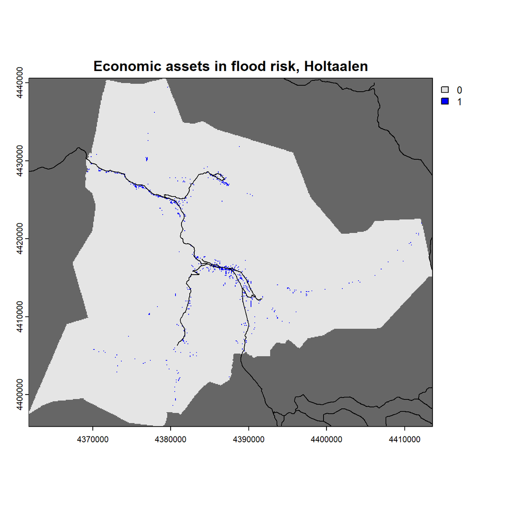

```r
# Holtålen
plot(sdam_econ %>% crop(hos,mask=T),col=ccsdam,colNA="grey40",
     main="Economic assets in flood risk, Holtaalen")
plot(hor,add=T)
```

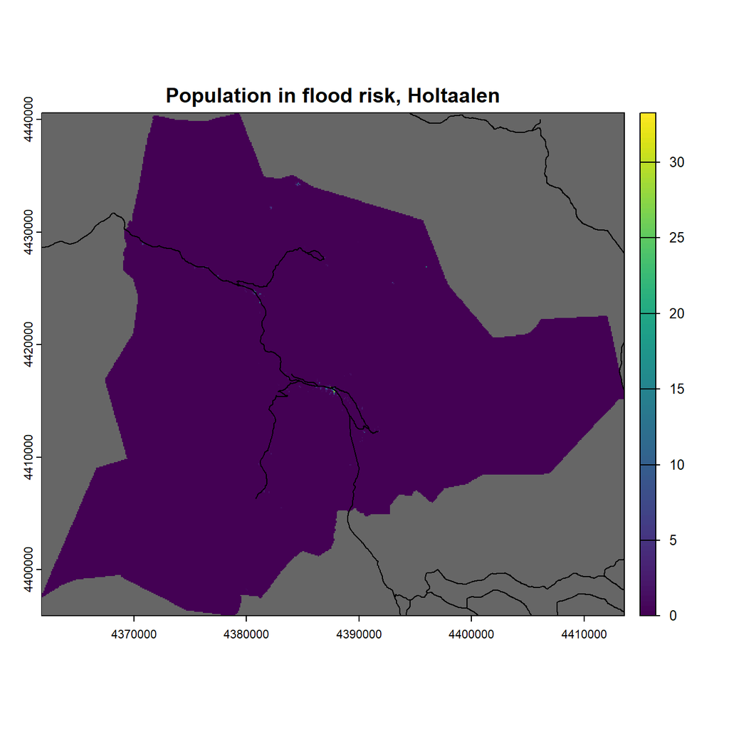

```r
plot(sdam_pop %>% crop(hos,mask=T),colNA="grey40",
     main="Population in flood risk, Holtaalen")
plot(hor,add=T)
```

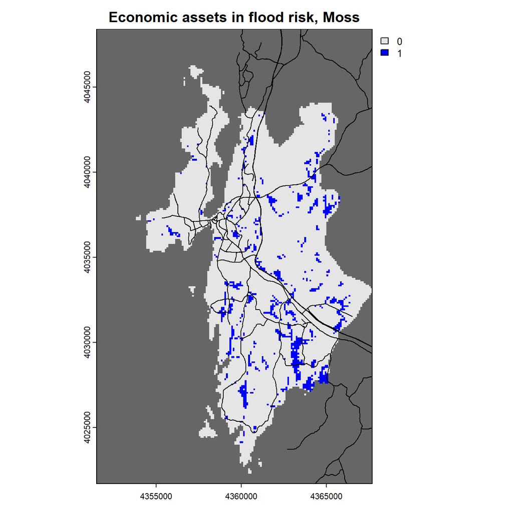

```r
#Moss
plot(sdam_econ %>% crop(mos,mask=T),col=ccsdam,colNA="grey40",
     main="Economic assets in flood risk, Moss")
plot(mor,add=T)
```

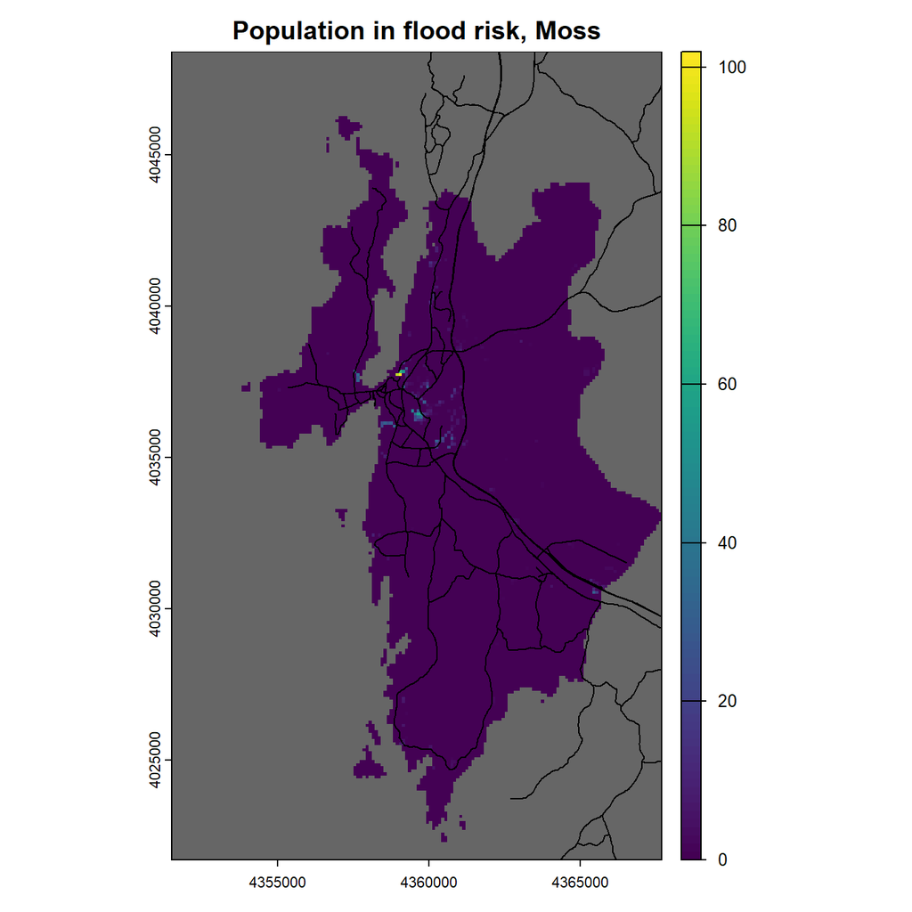

```r
plot(sdam_pop %>% crop(mos,mask=T),colNA="grey40",
     main="Population in flood risk, Moss")
plot(mor,add=T)
```

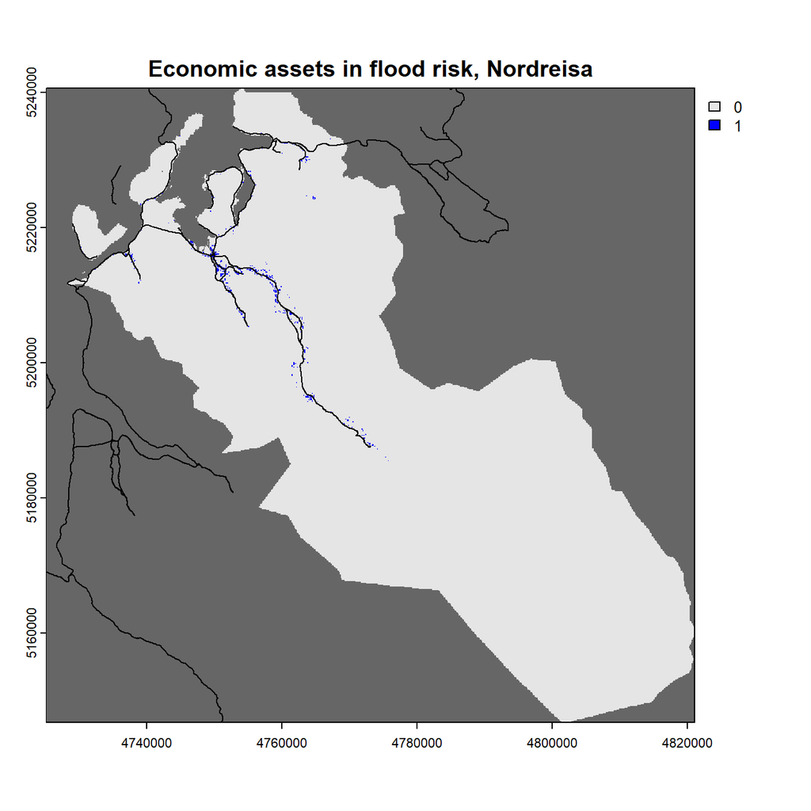

```r
# Nordreisa
plot(sdam_econ %>% crop(nrs,mask=T),col=ccsdam,colNA="grey40",
     main="Economic assets in flood risk, Nordreisa")
plot(nrr,add=T)
```

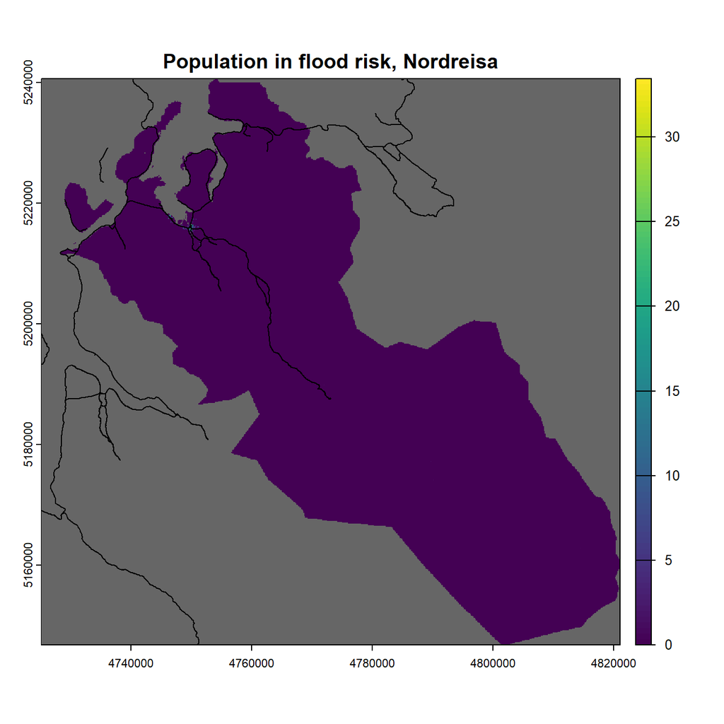

```r
plot(sdam_pop %>% crop(nrs,mask=T),colNA="grey40",
     main="Population in flood risk, Nordreisa")
plot(nrr,add=T)
```

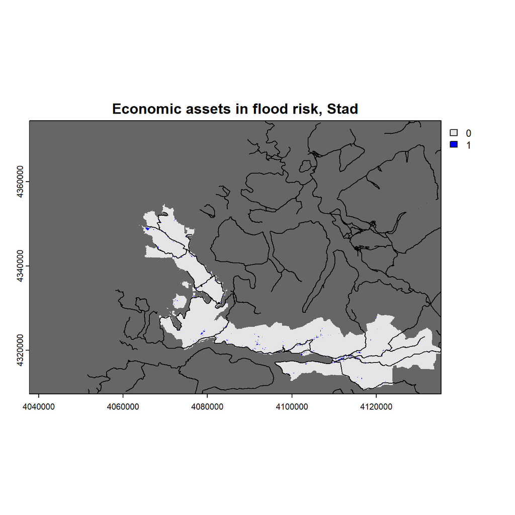

```r
# Stad
plot(sdam_econ %>% crop(sds,mask=T),col=ccsdam,colNA="grey40",
     main="Economic assets in flood risk, Stad")
plot(sdr,add=T)
```

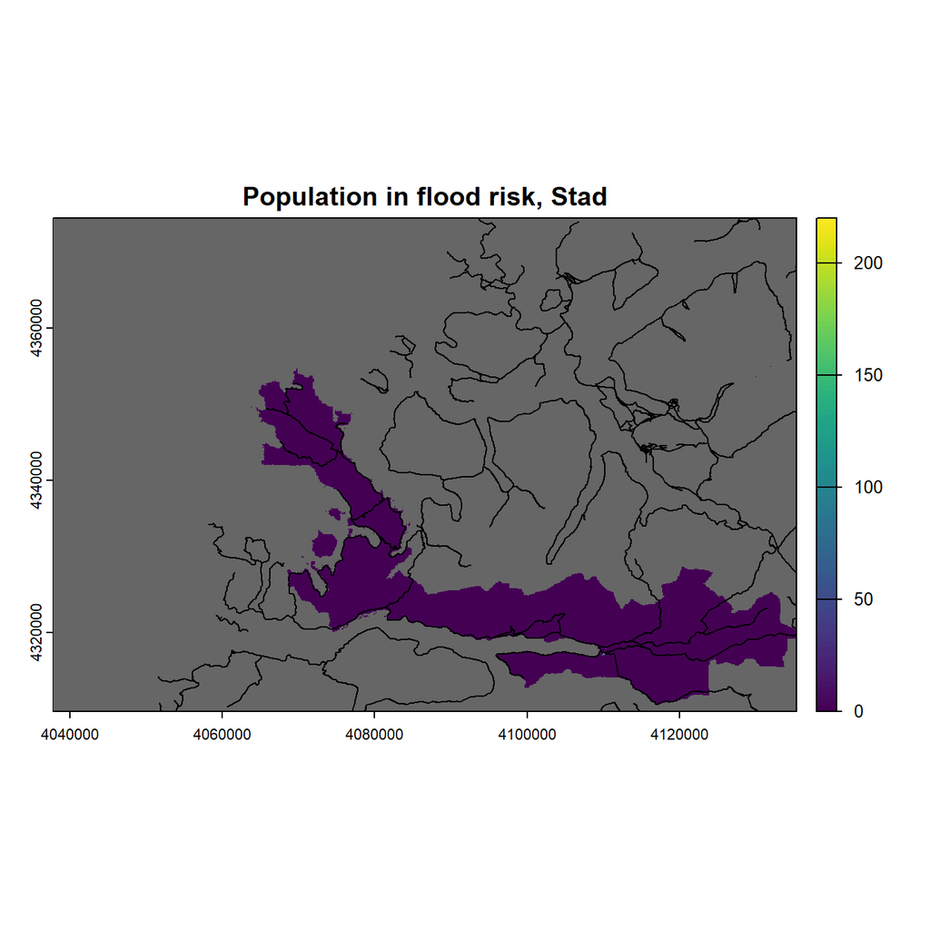

```r
plot(sdam_pop %>% crop(sds,mask=T),colNA="grey40",
     main="Population in flood risk, Stad")
plot(sdr,add=T)
```

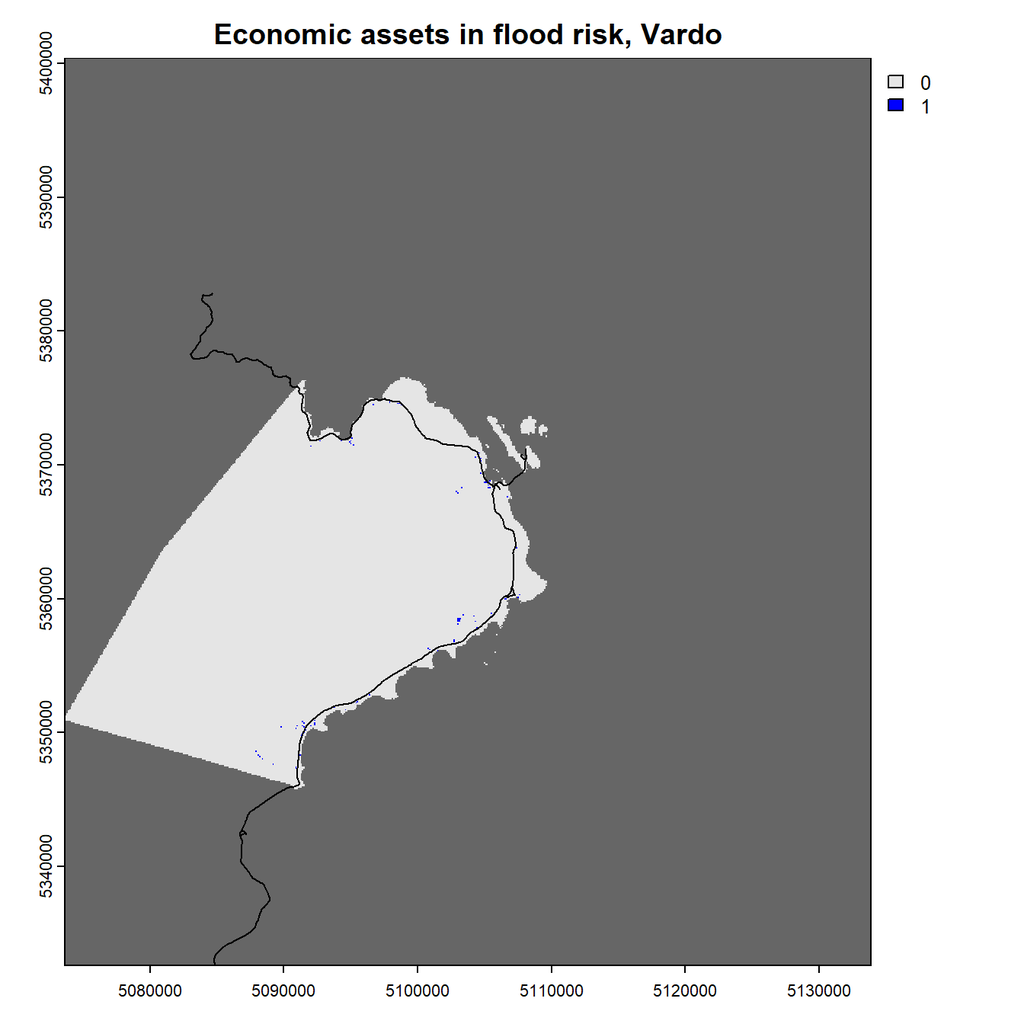

```r
# Vardø
plot(sdam_econ %>% crop(vrs,mask=T),col=ccsdam,colNA="grey40",
     main="Economic assets in flood risk, Vardo")
plot(vrr,add=T)
```

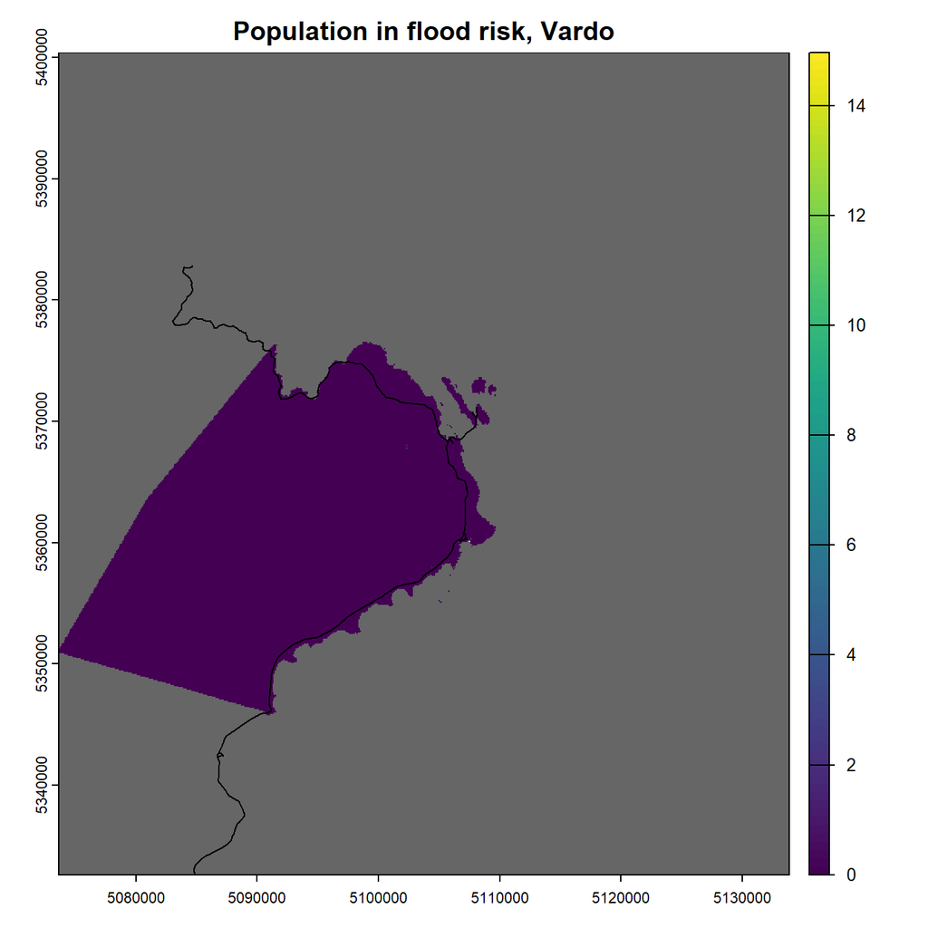

```r
plot(sdam_pop %>% crop(vrs,mask=T),colNA="grey40",
     main="Population in flood risk, Vardo")
plot(vrr,add=T)
```